# **Présentation** : Mission et Démarche

# Modélisation **SiteEnergyUseWN(kBtu)**

## 1) - Etapes Préliminaires

### Définition de constantes et mise en place d'options

```python
# liste des colonnes de nos df de présentations des résultats
LISTE_COL = ["Model", "Fit_Time", "Score_time", "MAE", "RMSLE", "R2"]

# Métriques utilisées en temps normal et au cas ou la MSLE ne soit pas adaptée
SCORING = ["neg_mean_absolute_error", "neg_mean_squared_log_error", "r2"]
SCORING_alt = ["neg_mean_absolute_error", "r2"]

# facteur aléatoire que nous utiliserons le long de notre travail
SEED = 47

# nombre de "folds" lors des validations croisées
K = 5

# instruction évitant les avertissements, nombreux lors de l'utilisation du modèle de TargetEncoder
warnings.filterwarnings('ignore')
warnings.simplefilter('ignore')

# augmentation du nombre de colonnes d'un objet DataFrame à visualiser
pd.options.display.max_columns = 30

# paramètres matplotlib & seaborn
font = {'family' : 'verdana',
        'weight' : 'normal',
        'size'   : 10}
plt.rc('font', **font)

sns.set(font_scale=0.9)
```

### Définition de notre **panel initial d'estimateurs** dans un dictionnaire.

```python
d_mod = {"Linear_Reg" : LinearRegression(),
        "Ridge_Reg" : Ridge(),
        "Lasso_Reg" : Lasso(),
        "SV_Reg" : SVR(),
        "DT_Reg" : DecisionTreeRegressor(),
        "RF_Reg" : RandomForestRegressor(random_state = SEED),
        "Adaboost_Reg" : AdaBoostRegressor(),
        "Bagging_Reg" : BaggingRegressor(base_estimator = DecisionTreeRegressor()),
        "GB_Reg" : GradientBoostingRegressor(random_state = SEED),
        "XGB_Reg" : xgboost.XGBRegressor(random_state = SEED)
       }
```

### Définition de notre fonction de **modélisation**

```python
def modelize(model, name, X, y, return_model = False , graph = False, k = K) :

    resultats = []

    kf = KFold(k, shuffle = True, random_state = SEED)

    try :
        cv_res = cross_validate(model, X, y, scoring = SCORING, cv = kf)

        resultats.append(name)
        resultats.append(cv_res["fit_time"].sum())
        resultats.append(cv_res["score_time"].sum())
        resultats.append(-cv_res['test_neg_mean_absolute_error'].mean())
        resultats.append(np.sqrt(-cv_res['test_neg_mean_squared_log_error']).mean())
        resultats.append(cv_res['test_r2'].mean())


    # Si, comme cela arrive parfois, la RMSLE est impossible à calculer, on lui donne la valeur 0.
    except :

        cv_res = cross_validate(model, X, y, scoring = SCORING_alt, cv = kf)

        resultats.append(name)
        resultats.append(cv_res["fit_time"].sum())
        resultats.append(cv_res["score_time"].sum())
        resultats.append(-cv_res['test_neg_mean_absolute_error'].mean())
        resultats.append(0)
        resultats.append(cv_res['test_r2'].mean())

    # affichage de graphs au choix
    if graph :

        pred = cross_val_predict(model, X, y, cv = kf)

        error = np.abs(y - pred)

        fig = plt.figure(figsize = (7, 7))
        plt.subplot(2,2,1)
        plt.scatter(y, pred, color = "coral")
        plt.subplot(2,2,2)
        plt.hist(error, bins = 50)
        plt.show()

    new_row = {k:v for k, v in zip(LISTE_COL, resultats)}

    # récupération d'un modèle entrainé au choix
    if return_model :

        return new_row, model.fit(X, y)

    else :

        return new_row
```

### Chargement des **données**

```python
# chargement de nos données avec et sans outliers
X = pickle.load(open("Data/X.pickle", "rb"))
y = pickle.load(open("Data/y.pickle", "rb"))

X_no = pickle.load(open("Data/X_no.pickle", "rb"))
y_no = pickle.load(open("Data/y_no.pickle", "rb"))

# Cibles du premier modèle (variable "SiteEnergyUseWN(kBtu)")
y = y["SiteEnergyUseWN(kBtu)"]
y_no = y_no["SiteEnergyUseWN(kBtu)"]

# transformation log(p+1) des cibles
y = y.transform(np.log1p)
y_no = y_no.transform(np.log1p)
```

### Définition de fonctions de **pre-processing**

```python
# Fonction d'imputation des valeurs manquantes de la variable EnergyStarScore
# Ici on impute la valeur médiane aux valeurs manquante.

def num_imput(X):

    med = X["ENERGYSTARScore"].median()
    X["ENERGYSTARScore"] = X["ENERGYSTARScore"].fillna(med)

    return X

# Fonction appliquant les transformations de nos variables quantitatives.

def num_trans(X):

    num_feat = np.array(X.columns[X.dtypes != "category"])

    for col in num_feat :

        X[col] = X[col].transform(np.log1p) # transformation "log(p +1)"
        std = StandardScaler().fit(np.array(X[col]).reshape(-1,1)) # standardisation
        X[col] = std.transform(np.array(X[col]).reshape(-1,1))

    return X

# fonction d'encodage de nos variables catégorielles
# ici c'est du OneHotEncoding grâce à pd.get_dummies()

def cat_trans(X):

    cat_feat = np.array(X.columns[X.dtypes == "category"])
    X = pd.get_dummies(X, drop_first = True)

    return X

# fonction de transformation globale regroupant les deux fonctions précédentes

def prepro(X):

    X = num_imput(X)
    X = num_trans(X)
    X = cat_trans(X)

    return X
```

## 2) - 1ère Modélisation encodage **One-Hot-Encoding**

```python
# Preprocessing

X = prepro(X)

# Initialisation du DataFrame de résultats

df_res = pd.DataFrame(columns = LISTE_COL)

# Boucle de modélisation

for name, model in d_mod.items():

    df_res = df_res.append(modelize(model, name, X, y), ignore_index = True)

df_res
```

|  | Model | Fit_Time | Score_time | MAE | RMSLE | R2 |
| --- | --- | --- | --- | --- | --- | --- |
| 0 | Linear_Reg | 0.566032 | 0.022001 | 0.338914 | 0.032464 | 0.808751 |
| 1 | Ridge_Reg | 0.154009 | 0.022001 | 0.331505 | 0.031672 | 0.818937 |
| 2 | Lasso_Reg | 0.139008 | 0.025001 | 0.892718 | 0.072055 | -0.002240 |
| 3 | SV_Reg | 5.481313 | 1.157067 | 0.315206 | 0.031702 | 0.814440 |
| 4 | DT_Reg | 0.250014 | 0.022001 | 0.453126 | 0.043561 | 0.652701 |
| 5 | RF_Reg | 13.329762 | 0.122007 | 0.337221 | 0.033635 | 0.794065 |
| 6 | Adaboost_Reg | 3.314189 | 0.100006 | 0.485778 | 0.042405 | 0.666339 |
| 7 | Bagging_Reg | 1.564089 | 0.063004 | 0.358547 | 0.035100 | 0.774771 |
| 8 | GB_Reg | 3.899223 | 0.027002 | 0.324564 | 0.031377 | 0.820839 |
| 9 | XGB_Reg | 2.417138 | 0.079005 | 0.316152 | 0.031195 | 0.823654 |

**Commentaires**  
Ces résultats constitue la base de travail que nous allons essayer d'améliorer.  
Parmi eux, le résultat de la regression **lasso** nous pose question. Il est étonnant de voir que ce modèle ne **"marche pas"** contrairement à ses modèles "voisin", **Régression Linéaire** et **Régression Ridge**.

Procédons à nouveau à la **régression Lasso**.

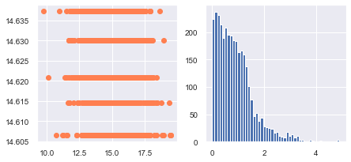

```
{'Model': 'lasso',
 'Fit_Time': 0.07900476455688477,
 'Score_time': 0.02800154685974121,
 'MAE': 0.892718476394694,
 'RMSLE': 0.07205524862298177,
 'R2': -0.0022402284744833523}
```

```python
#X = prepro(X)
lasso = Lasso()
modelize(lasso, "lasso", X, y, False, True)
```

Ces résultats sont ceux d'une régression lasso avec des hyper-paramètres "par défaut", notamment un coefficient **alpha** valant **1**.  
Nous allons observer l'évolution du résultat en faisant varier **alpha**.

Influence du paramètre **alpha**

```python
err_r2 = []
err_rmsle = []
err_mae = []
coefs = []

alphas = np.linspace(0.01,10,50)

for alpha in alphas :
    lasso = Lasso(alpha = alpha)
    cv_results = cross_validate(lasso, X, y, scoring = SCORING,
                                cv = KFold(K, shuffle = True, random_state = SEED))
    err_r2.append(cv_results['test_r2'].mean())
    err_rmsle.append(np.sqrt(-cv_results['test_neg_mean_squared_log_error'].mean()))
    err_mae.append(-cv_results['test_neg_mean_absolute_error'].mean())
```

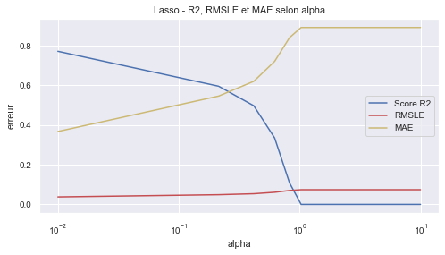

```python
fig = plt.figure(figsize = (8,4))
plt.plot(alphas, err_r2, label = "Score R2", color = "b")
plt.plot(alphas, err_rmsle, label = "RMSLE", color = "r")
plt.plot(alphas, err_mae, label = "MAE", color = "y")
plt.xscale('log')
plt.xlabel('alpha')
plt.ylabel('erreur')
plt.title('Lasso - R2, RMSLE et MAE selon alpha')
plt.legend()
plt.show()
```

On voit que les scores dans les différentes métriques sont les meilleurs lorsque **alpha = 0**, c'est dire quand le lasso équivaut à une régression linéaire classique, et que les scores se détériorent jusqu'à devenir constants quand **alpha = 1**. Cela nous montre que le lasso ne fonctionne pas avec nos données.

## 3) - Modélisation **OHE** sans Outliers

```python
# Init du DF de résultats
df_no = pd.DataFrame(columns = LISTE_COL)

# Preprocessing
X_no = prepro(X_no)

for name, model in d_mod.items():

    df_no = df_no.append(modelize(model, name, X_no, y_no), ignore_index = True)

df_no
```

|  | Model | Fit_Time | Score_time | MAE | RMSLE | R2 |
| --- | --- | --- | --- | --- | --- | --- |
| 0 | Linear_Reg | 0.143008 | 0.024002 | 8.015078e+08 | 0 | -2.986403e+20 |
| 1 | Ridge_Reg | 0.071004 | 0.022001 | 3.315077e-01 | 0.0320662 | 7.794114e-01 |
| 2 | Lasso_Reg | 0.061004 | 0.020001 | 8.158383e-01 | 0.066332 | -4.973718e-04 |
| 3 | SV_Reg | 4.790272 | 1.023059 | 3.105486e-01 | 0.0316236 | 7.844752e-01 |
| 4 | DT_Reg | 0.239014 | 0.020001 | 4.484207e-01 | 0.0439855 | 5.832466e-01 |
| 5 | RF_Reg | 11.960684 | 0.120005 | 3.348258e-01 | 0.0333053 | 7.599233e-01 |
| 6 | Adaboost_Reg | 3.185180 | 0.093005 | 4.747513e-01 | 0.042147 | 6.087202e-01 |
| 7 | Bagging_Reg | 1.379079 | 0.060004 | 3.535642e-01 | 0.0349224 | 7.362879e-01 |
| 8 | GB_Reg | 3.533203 | 0.028001 | 3.210211e-01 | 0.0312502 | 7.885876e-01 |
| 9 | XGB_Reg | 2.276130 | 0.064003 | 3.189408e-01 | 0.0321969 | 7.766159e-01 |

Un résultat un peu paradoxale. Nous pensions que sans **outliers**, c'est à dire avec données plus homogènes puisque débarassées d'un certain nombres d'observations comportant des valeurs extrêmes, nous aurions pu obtenir de meilleurs résultats.  
Or ceux-ci semblent clairement moins bons en plus d'apporter des résultats problématiques en **RL** et **Lasso**.  
Du coup, nous **laissons tomber** cette piste d'amélioration pour n'y revenir éventuellement qu'en fin d'étude.

## 4) - Discussion **EnergyStarScore** - Premiers Regards

Rappelons qu'au départ, cette variable contient une proportion notable de valeurs nulles.

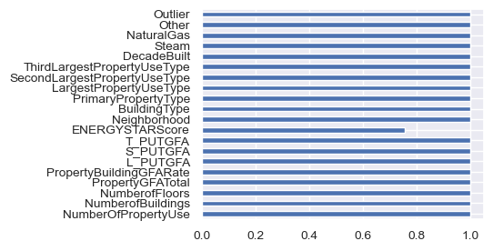

```python
X_raw = pickle.load(open("Data/X.pickle", "rb"))

sns.set(font_scale=0.9)
fig = plt.figure(figsize = (4, 3))
X_raw.notnull().mean().plot.barh()
plt.show()
```

En vue de nos modélisations avec elle, plutôt que de diminuer notre échantillon de données en nous séparant des observations dont sa valeur serait nulle, nous avions imputé sa valeur médiane à ses valeurs manquantes.

### **Régression ridge**

```python
# Rappel des résultats avec ESS
liste, mod = modelize(Ridge(), "regression ridge", X, y, True)
liste
```

```
{'Model': 'regression ridge',
 'Fit_Time': 0.08400464057922363,
 'Score_time': 0.02500152587890625,
 'MAE': 0.3315054101178619,
 'RMSLE': 0.03167185865883354,
 'R2': 0.8189374960278606}
```

### Graph des **coefs** du modèle

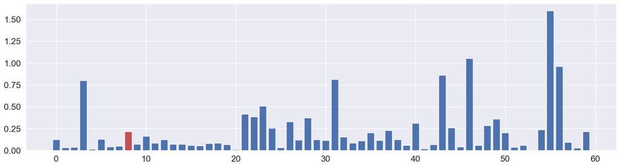

```python
importance = pd.Series(mod.coef_, range(len(mod.coef_)))

color = ["b"]*len(mod.coef_)
color[8] = "r"

fig = plt.figure(figsize = (20, 5))
sns.set(font_scale=1.5)
plt.bar(importance.index[:60], np.abs(importance.values)[:60], color = color)
plt.show()
```

Même modélisation sans la variable **ENERGYSTARScore**

```python
X_ses = X.drop("ENERGYSTARScore", axis = 1)
```

```python
# résultats sabs ESS
liste, mod = modelize(Ridge(), "regression ridge", X_ses, y, True)
liste
```

```
{'Model': 'regression ridge',
 'Fit_Time': 0.0760042667388916,
 'Score_time': 0.024001598358154297,
 'MAE': 0.3708046712120974,
 'RMSLE': 0.034419336649194415,
 'R2': 0.7853735420109292}
```

### **Random forest**

```python
liste, mod = modelize(RandomForestRegressor(random_state = SEED), "random forest reg", X, y, True)
liste
```

```
{'Model': 'random forest reg',
 'Fit_Time': 13.415767192840576,
 'Score_time': 0.12200713157653809,
 'MAE': 0.3372207674800788,
 'RMSLE': 0.03363469478370986,
 'R2': 0.7940652368731562}
```

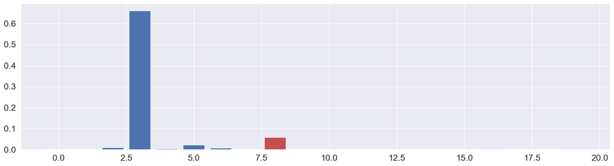

```python
importance = pd.Series(mod.feature_importances_,
                       range(len(mod.feature_importances_)))

color = ["b"]*len(mod.feature_importances_)
color[8] = "r"

fig = plt.figure(figsize = (20,5))
plt.bar(importance.index[:20], np.abs(importance.values)[:20], color = color)
plt.show()
```

```python
mod.feature_importances_[8]
```

```
0.05932260267170293
```

Avec un estimateur RF, l'importance de l'ESS peut être quantifiée à **5,9 %**.

```python
liste, mod = modelize(RandomForestRegressor(random_state = SEED), "random forest reg", X_ses, y, True)
liste
```

```
{'Model': 'random forest reg',
 'Fit_Time': 12.530714273452759,
 'Score_time': 0.11900687217712402,
 'MAE': 0.38735340374321897,
 'RMSLE': 0.03726942344804566,
 'R2': 0.7480258691539852}
```

Là encore les résultats sont moins bons...

### **xgboost**

```python
liste, mod = modelize(xgboost.XGBRegressor(random_state = SEED), "XGBoost", X, y, True)
liste
```

```
{'Model': 'XGBoost',
 'Fit_Time': 2.267129421234131,
 'Score_time': 0.06800365447998047,
 'MAE': 0.31615174162161275,
 'RMSLE': 0.03119492739420952,
 'R2': 0.8236544069017133}
```

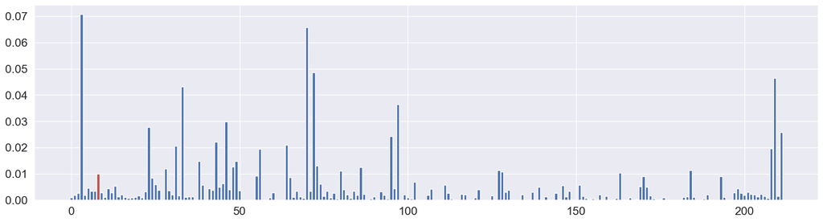

```python
color = ["b"]*len(mod.feature_importances_)
color[8] = "r"

fig = plt.figure(figsize = (20,5))
plt.bar(range(len(mod.feature_importances_)), mod.feature_importances_, color = color)
plt.show()
```

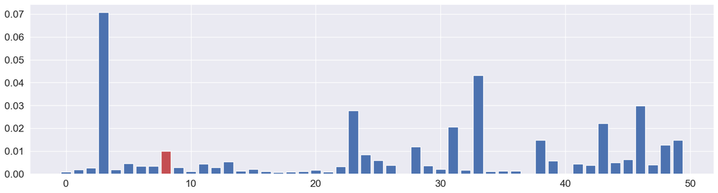

```python
# zoom
fig = plt.figure(figsize = (20,5))
plt.bar(range(len(mod.feature_importances_[:50])), mod.feature_importances_[:50], color = color)
plt.show()
```

```python
mod.feature_importances_[8]
```

```
0.01000348
```

Avec XGBoost, l'indicateur compte pour **1%**.

```python
liste, mod = modelize(xgboost.XGBRegressor(random_state = SEED), "XGBoost", X_ses, y, True)
liste
```

```
{'Model': 'XGBoost',
 'Fit_Time': 2.1351218223571777,
 'Score_time': 0.06400370597839355,
 'MAE': 0.3769052191009289,
 'RMSLE': 0.03559620597237821,
 'R2': 0.7712276082184132}
```

Ici aussi, se passer de la variable **EnergyStarScore** diminue la qualité de la modélisation.

## 5) - Modélisation encodage **Label Encoding**

Ce type d'encodage réduit la complexité des modèles, donc sa variance, mais augmente aussi son biais en modifiant l'information portée par les variables catégorielles, notamment en les transformant en variables ordinales.

On va encoder nos données en amont du pipeline qui devra être aussi modifié...

```python
X_lab = pickle.load(open("Data/X.pickle", "rb"))

X_lab = num_imput(X_lab)
X_lab = num_trans(X_lab)

cat_feat = np.array(X_lab.columns[X_lab.dtypes == "category"])

for cat in cat_feat :
    lab_enc = LabelEncoder()
    X_lab[cat] = lab_enc.fit_transform(X_lab[cat])
```

```python
df_res_lab = pd.DataFrame(columns = LISTE_COL)

for name, model in d_mod.items():

    df_res_lab = df_res_lab.append(modelize(model, name, X_lab, y), ignore_index = True)

df_res_lab
```

|  | Model | Fit_Time | Score_time | MAE | RMSLE | R2 |
| --- | --- | --- | --- | --- | --- | --- |
| 0 | Linear_Reg | 0.020001 | 0.017001 | 0.398173 | 0.037548 | 0.741061 |
| 1 | Ridge_Reg | 0.018001 | 0.015001 | 0.398118 | 0.037548 | 0.741067 |
| 2 | Lasso_Reg | 0.018001 | 0.012001 | 0.891936 | 0.071994 | -0.000587 |
| 3 | SV_Reg | 1.285073 | 0.210011 | 0.418859 | 0.039914 | 0.705016 |
| 4 | DT_Reg | 0.094006 | 0.014000 | 0.491527 | 0.048415 | 0.573796 |
| 5 | RF_Reg | 5.692326 | 0.096006 | 0.346239 | 0.034558 | 0.781744 |
| 6 | Adaboost_Reg | 0.911052 | 0.044003 | 0.500670 | 0.042591 | 0.661995 |
| 7 | Bagging_Reg | 0.593034 | 0.026001 | 0.373430 | 0.036294 | 0.758624 |
| 8 | GB_Reg | 1.625092 | 0.017001 | 0.328904 | 0.031906 | 0.814005 |
| 9 | XGB_Reg | 0.505029 | 0.024001 | 0.324810 | 0.031434 | 0.819108 |

Résultats un peu moins bons que les résultats initiaux.  
Comme on pouvait s'y attendre, les estimateurs linéaires sont plus impactés car pour eux, la transformation certaines des données catégorielles prennent une **connotation ordinale** qui détériore les données.

## 6) - Modélisation encodage **Target Encoding**

Le Target encoding consiste à remplacer les catégories d'une variable par la moyenne des valeurs cibles correspondantes.

```python
X_tar = pickle.load(open("Data/X.pickle", "rb"))

X_tar = num_imput(X_tar)
X_tar = num_trans(X_tar)

cat_feat = np.array(X_tar.columns[X_tar.dtypes == "category"])

for cat in cat_feat :
    tar_enc = TargetEncoder()
    X_tar[cat] = tar_enc.fit_transform(X_tar[cat], y)
```

```python
df_res_tar = pd.DataFrame(columns = LISTE_COL)

for name, model in d_mod.items():

    df_res_tar = df_res_tar.append(modelize(model, name, X_tar, y), ignore_index = True)

df_res_tar
```

|  | Model | Fit_Time | Score_time | MAE | RMSLE | R2 |
| --- | --- | --- | --- | --- | --- | --- |
| 0 | Linear_Reg | 0.020001 | 0.016001 | 0.348414 | 0.033181 | 0.800804 |
| 1 | Ridge_Reg | 0.018001 | 0.014000 | 0.348322 | 0.033180 | 0.800819 |
| 2 | Lasso_Reg | 0.014000 | 0.012001 | 0.892718 | 0.072055 | -0.002240 |
| 3 | SV_Reg | 1.197069 | 0.193011 | 0.359050 | 0.034426 | 0.786175 |
| 4 | DT_Reg | 0.095005 | 0.011000 | 0.454060 | 0.044738 | 0.640698 |
| 5 | RF_Reg | 5.569317 | 0.095006 | 0.322909 | 0.031753 | 0.817204 |
| 6 | Adaboost_Reg | 0.909052 | 0.040002 | 0.427782 | 0.037556 | 0.739301 |
| 7 | Bagging_Reg | 0.580033 | 0.023002 | 0.340522 | 0.032872 | 0.803054 |
| 8 | GB_Reg | 1.628093 | 0.017000 | 0.313794 | 0.030254 | 0.834044 |
| 9 | XGB_Reg | 0.593034 | 0.022001 | 0.319759 | 0.031134 | 0.824803 |

Le Target Encoding nous permet d'obtenir une amélioration de nos modèles notamment avec le **Random Forest** et le **Gradient Boosting**.

## 7) - **Sélection** des meilleurs estimateurs

Suite à nos précédents résultats, nous décidons, en vue de la suite, de garder les models les plus prometteurs :  
- **ridge** + OHE  
- **SVR** + OHE  
- **Random Forest** + TE  
- **Gradient Boosting** + TE

## 8) - **Réduction dimensionnelle** "*expérimentale*"

### Utilisation de la fonction **Optimize_Level**

Il s'agit d'un script fonctionnant en "force brute" qui peut permettre de diminuer le "level" (le nombre de valeurs différentes...) des variables catégorielles si cela augmente les performances des modèles.

```python
# En fonction d'un level "n", et d'une colonne "col" (d'une variable catégorielle) d'un DF "df",
# cette méthode renvoie une colonne "col" réduite à "n" différentes valeurs. le surplus est
# remplacé par "No_Data" ou des "0"

def level_n_reductor(n, df, col):

    df1 = df.copy()

    top = df1[col].value_counts().index.tolist()[:n]

    labels = df1[col].value_counts().index.tolist()

    type_data = type(labels[0])

    if type_data is str :

        new = [l if l in top else "No_Data" for l in labels]

    else :

        new = [l if l in top else 0 for l in labels]

    dico = {k:v for k, v in zip(labels, new)}

    df1[col] = df1[col].map(dico)
    df1[col] = df1[col].astype("category")


    nb = df1[col].unique().shape[0]

    return df1, nb



# modélisation renvoyant les résultats dans la métrique "key"

def modeli(n, model, X, y, key) :

    resultats = [n]

    kf = KFold(K, shuffle = True, random_state = SEED)

    cv_res = cross_validate(model, X, y, scoring = SCORING, cv = kf)

    dict_metrics = {"MAE" : -cv_res['test_neg_mean_absolute_error'].mean(),
                    "RMSLE" : np.sqrt(-cv_res['test_neg_mean_squared_log_error']).mean(),
                    "R2" : cv_res['test_r2'].mean()}

    resultats.append(dict_metrics[key])

    return resultats


# Pour un df, un model, et une métrique donnés, cette méthode cherche le meilleur level de chaque
# variable catégorielle en allant de la varcat la PLUS PROFONDE à la MOINS PROFONDE.

def optimize_level(model, model_name, df, y, key, encode = "One_Hot"):

    X = df.copy()

    # init de listes
    liste = []
    liste_best = []
    liste_X_trans = []
    liste_indice = []

    # listage des var.cat. d'un DF
    liste_var_cat = X.select_dtypes(include="category").columns.to_list()

    # création d'une série (classée decroi.) de ces var.cat. avec leur level en index
    s = pd.Series([k for k in liste_var_cat],
                  index = [X[var].unique().shape[0] for var in liste_var_cat]).sort_index(ascending = False)

    # boucle dans la série
    for col, n in zip(s.values, s.index) :

        # init de listes
        liste_X = []
        liste_n = []

        # pour la colonne col, on crée une liste de df ou col a son level diminué de n à 1
        for i in range(n, 0, -1) : # yo +1

            liste_X.append(level_n_reductor(i, X, col)[0])
            liste_n.append(level_n_reductor(i, X, col)[1])

        liste_b = []
        i = 0

        # on calcule le score pour chaque df
        for dataf, nb in zip(liste_X, liste_n) :

            df1 = dataf.copy()

            if encode == "One_Hot":

                df1 = pd.get_dummies(df1, drop_first = True)

            else :

                cat_feat = np.array(df1.columns[(df1.dtypes == "category")|(df1.dtypes == "object")])

                for cat in cat_feat :
                    tar_enc = TargetEncoder().fit(df1[cat], y)
                    df1[cat] = tar_enc.transform(df1[cat])

            liste_b.append([i] + list(modeli(nb, model, df1, y, key))) #yoooo +1
            if i == 0:
                print(f"Score de départ pour la variable {col} : {liste_b[0][2]}")


            i += 1

        # on récupère meileur score et meilleur indice n correspondant
        ar_b = np.array(liste_b)

        if key == "RMSLE" :

            best = np.min(ar_b, axis = 0)[2]
            ind = np.argmin(ar_b, axis = 0)[2]

        else :

            best = np.max(ar_b, axis = 0)[2]
            ind = np.argmax(ar_b, axis = 0)[2]

        best_n = int(ar_b[ind][1])

        liste.append(liste_b)
        liste_best.append((i, ind, best, best_n))
        liste_indice.append(best_n)

        print(f"Score optimisé à {best}, nombre de catégories de la variable passé de {n} à {best_n}")
        print()

        # Actualisation de X qui sera utilisée dans la suite de la boucle
        X = liste_X[ind]
        liste_X_trans.append(X)

    # sortie de la boucle, abandon des variables devenues cst.
    X_opti = liste_X_trans[-1]

    for col in liste_var_cat :

        if X_opti[col].unique().shape[0] == 1 :

            X_opti = X_opti.drop(col, axis = 1)

    # on retourne les meilleurs score et indice, ainsi que le df ainsi "optimisé"
    return liste_best, model_name, liste_best[-1][2], X_opti
```

### Optimisation **Ridge** et **SVR**

On procède avec les estimateurs **ridge** et **SVR** combinés à un encodage **One Hot**.

```python
X = pickle.load(open("Data/X.pickle", "rb"))
X = num_imput(X)
X = num_trans(X)

red_level_ohe = []

select_mod_ohe = {"Ridge_Reg" : Ridge(),
                  "SV_Reg" : SVR()}
```

```python
for name, mod in select_mod_ohe.items() :
#for name, mod in zip(modz.keys()[:2], modz.values()[:2]) :
    start = time()
    print()
    print(f"Optimisation du dataset pour le modèle {name}")
    print()
    red_level_ohe.append(optimize_level(mod, name, X, y, "RMSLE"))
    print(f"Meilleur score obtenu : {red_level_ohe[-1][2]}")
    #print(red_level_ohe[-1][1], red_level_ohe[-1][2])
    print(f"on a mis {time() - start} secondes")
    print()

for l in red_level_ohe :

    print(l[1], l[2], f"{len(X.columns) - len(l[3].columns)} colonne(s) drop")

pickle_out = open("Data/red_level_ohe.pickle", "wb")
pickle.dump(red_level_ohe, pickle_out)
pickle_out.close()
```

[output not shown]

[output cut: 24 more lines]

[output not shown]

### Optimisation **Random Forest** et **Gradient Boosting**

**RF** et **GB** avec encodage **Target Encoding**

```python
X = pickle.load(open("Data/X.pickle", "rb"))
X = num_imput(X)
X = num_trans(X)

red_level_tar = []

select_mod_tar = {"RF_Reg" : RandomForestRegressor(random_state = SEED),
                  "GB_Reg" : GradientBoostingRegressor(random_state = SEED)}
```

```python
for name, mod in select_mod_tar.items() :
#for name, mod in zip(modz.keys()[:2], modz.values()[:2]) :
    start = time()
    print(f"Optimisation du dataset pour le modèle {name}")
    print()
    red_level_tar.append(optimize_level(mod, name, X, y, "RMSLE", "Target"))
    print(f"Meilleur score obtenu : {red_level_tar[-1][2]}")
    print(f"on a mis {time() - start} secondes")
    print()

for l in red_level_tar :

    print(l[1], l[2], f"{len(X.columns) - len(l[3].columns)} colonne(s) drop")

pickle_out = open("Data/red_level_tar.pickle", "wb")
pickle.dump(red_level_tar, pickle_out)
pickle_out.close()
```

[output not shown]

A partir de maintenant, suite à cette "optimisation", chaque estimateur aura son **propre dataset optimisé associé**.

```python
liste_ohe = pickle.load(open("Data/red_level_ohe.pickle", "rb"))
liste_tar = pickle.load(open("Data/red_level_tar.pickle", "rb"))
```

```python
X_ridge = liste_ohe[0][3]
X_svr = liste_ohe[1][3]
X_rf = liste_tar[0][3]
X_gb = liste_tar[1][3]
```